# Fake Headline Detection

Brandon Chan

## Introduction

[figure not shown]

Headlines are a problem. In today’s world, it feels like headlines are more inflamatory than informative, engineered to get a reaction. The big problem with headlines is that a lot of people read them and form an opinion without reading the article it’s attached to. It’s an *even* bigger problem considering the prevalence of fake news. These headlines swing the opinions of millions of people and keep people misinformed. So in writing this report, I want to learn a little more about the problem at hand, specifically, what drives the differences between real and fake headlines and how easy it is to distinguish real and fake headlines.

## **Goal**

### The Data I Will Be Using

- I will be using a random sample of 2,000 out of the 44,689 articles. *My tiny 13-inch laptop simply can’t even begin to handle that much text processing on all 44,689 articles, so the actual data used will be a representative sample of the original data set.
- 2,000 article headlines
  - 1048 real
  - 952 fake

This is a peek into the data I’ll be working with.

```r
sampled.df <- read.csv("C:/Users/Computadora/Documents/434 final/files/sampled.csv", stringsAsFactors = F)
head(sampled.df) %>% mutate(title = substr(title, 1, 60)) #shortening titles
```

```
##                                                          title truth
## 1  WATCH: Reince Priebus Gives The Stupidest Reason EVER For W  fake
## 2 Mnuchin says business tax rate at 15 percent in Trump tax pl  real
## 3 Peru cancels copper project auction amid political crisis: s  real
## 4  BUSTED: Steel Unions FURIOUS At Trump For Destroying Americ  fake
## 5 BOOM! TRUMP Announces CHRISTIAN Syrians Applying For Refugee  fake
## 6 Turkey orders detention of 216 people in post-coup probe: An  real
```

### Processing the Data

The data in the original format is not ready for analysis.  
To prepare the text for analysis I:

- Got rid of whitespace
- Got rid of puncuation
- Got rid of numbers
- Made everything lower case
- Got rid of words with no meaning (ex. “the”, “and”, “it”, etc.)

The main purpose of this processing is to only keep the meaningful characters and words in the headlines and get rid of everything else.

Next, I tokenized the text. This means I turned headlines into a list of words. Fundamentally, all this involves, is turning a sentence string, into a list of word strings.

This results in a total of 5,527 total unique words, but I will only keep the top 1000 most frequent words. I am only keeping the top 1000 because the top 1000 words are the words that best distinguish headlines. Words outside of the top 1000 are usually just words that appear in one or two headlines total. Another reason is because of my tiny laptop. I’ve tried with all 5,527 words and my laptop crashes when fitting complex models like random forest.

Finally, I keep the top 1000 most prominent words and I calculated the TFIDF value for all 1000 words in every headline. Here, The TFIDF value simply represents the ratio of the number of times a word appears in a headline and the number of headlines that contain the word. This ratio is a great measure of how well a word distinguishes headlines. The more a word appears in a single headline, the more it distinguishes that headline. But the more a word appears in all headlines, the less it distinguishes headlines overall.

So this is the final data set I’ll be working with:

- 2,000 rows. One for each headline.
- 1,001 columns. 1,000 words and whether or not the article is real or fake.
- 2,000,000 TFIDF values

```r
df <- read.csv("C:/Users/Computadora/Documents/434 final/files/tf_idf.csv")
head(df)[700:705]
```

```
##   proves public puerto push putin qaeda
## 1      0      0      0    0     0     0
## 2      0      0      0    0     0     0
## 3      0      0      0    0     0     0
## 4      0      0      0    0     0     0
## 5      0      0      0    0     0     0
## 6      0      0      0    0     0     0
```

As you can see, almost all of the TFIDF values are 0. This is because to have a TFIDF value greater than 0, the word has to appear in the headline and most words only appear in small number of headlines.

## Exploring the Data

Let’s make some word clouds.

```r
real.words <- paste((sampled.df %>% filter(as.character(truth) == "real"))$title, collapse = " ")
fake.words <- paste((sampled.df %>% filter(as.character(truth) == "fake"))$title, collapse = " ")
```

#### Word Cloud From Real Headlines

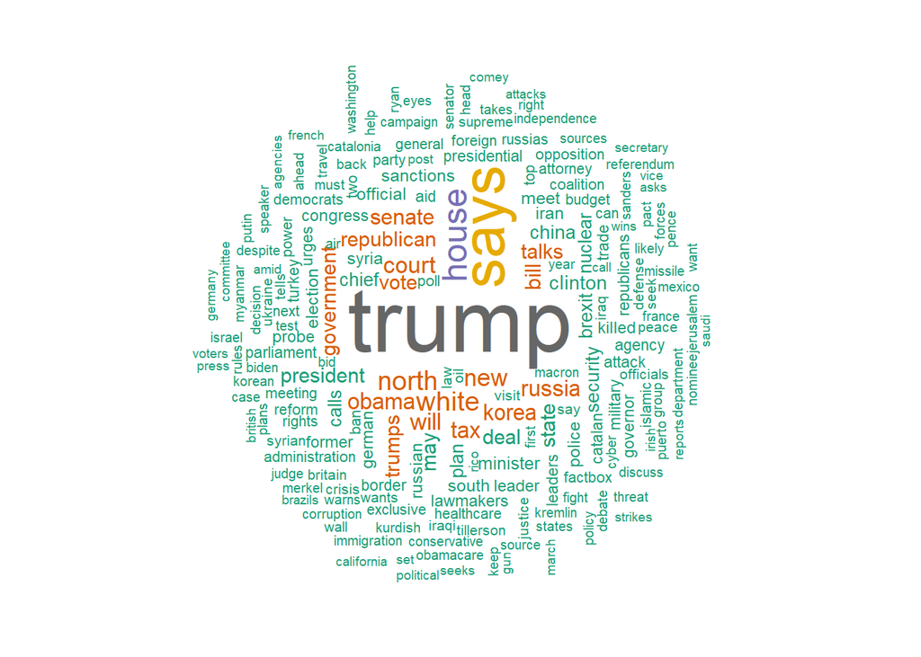

```r
rquery.wordcloud(real.words, lang = "english", excludeWords = stopwords(kind = "en"), textStemming = F)
```

#### Word Cloud From Fake Headlines

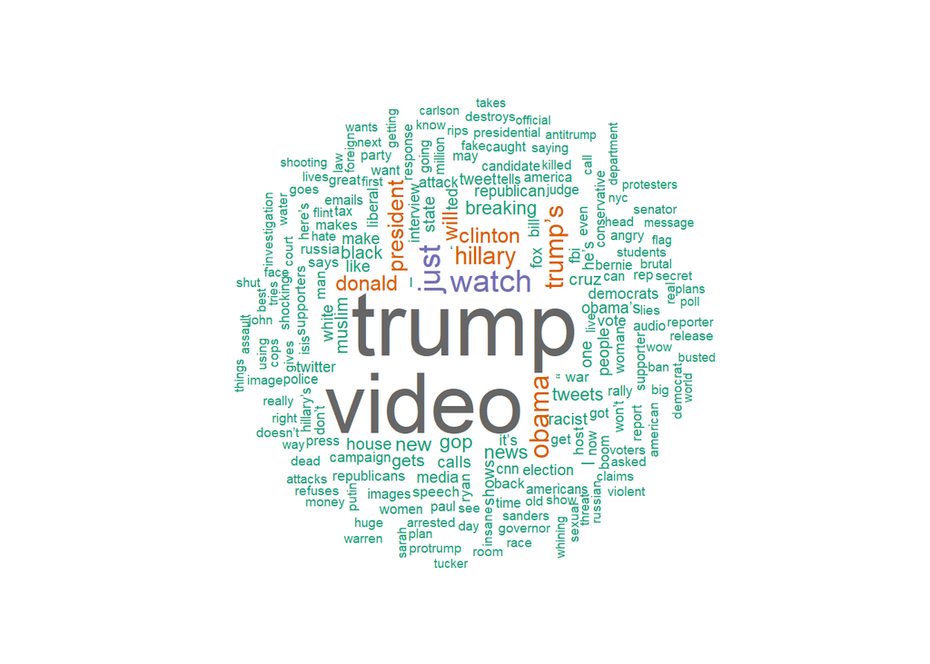

```r
rquery.wordcloud(fake.words, lang = "english", excludeWords = stopwords(kind = "en"), textStemming = F)
```

The biggest difference in these word clouds is the word “video.” “Video” is the second most prominent word in the fake headlines and not a prominent word at all in the real headlines. The most prominent words in the real headlines are general political topics, but the most prominent words in the fake headlines are names.

We can quantify the prominence by looking at a barchart of the frequency of the most prominent words.

```r
word.counts <- sampled.df %>%
  unnest_tokens(word, title) %>%
  filter(nchar(word) > 1) %>%
  anti_join(stop_words) %>%
  count(word) %>%
  arrange(desc(n))

real.word.counts <- sampled.df %>%
  filter(as.character(truth) == "real") %>%
  unnest_tokens(word, title) %>%
  filter(nchar(word) > 1) %>%
  anti_join(stop_words) %>%
  count(word) %>%
  top_n(10, n) %>%
  arrange(desc(n))

fake.word.counts <- sampled.df %>%
  filter(as.character(truth) == "fake") %>%
  unnest_tokens(word, title) %>%
  filter(nchar(word) > 1) %>%
  anti_join(stop_words) %>%
  count(word) %>%
  top_n(10, n) %>%
  arrange(desc(n))
```

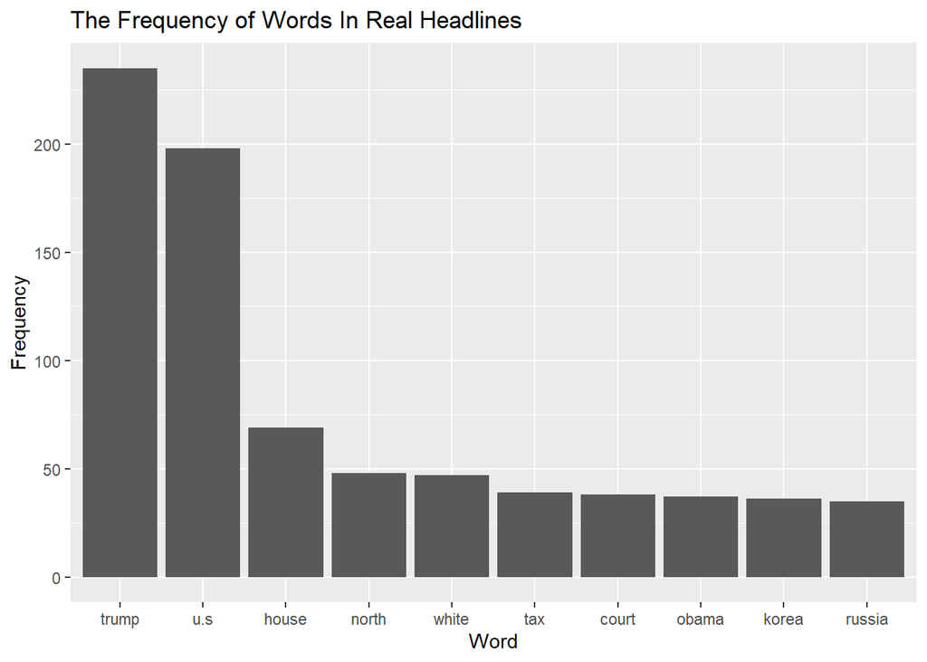

```r
ggplot(real.word.counts, aes(x = reorder(word, - n), y = n)) + geom_col() +
  xlab("Word")+
  ylab("Frequency")+
  ggtitle("The Frequency of Words In Real Headlines")
```

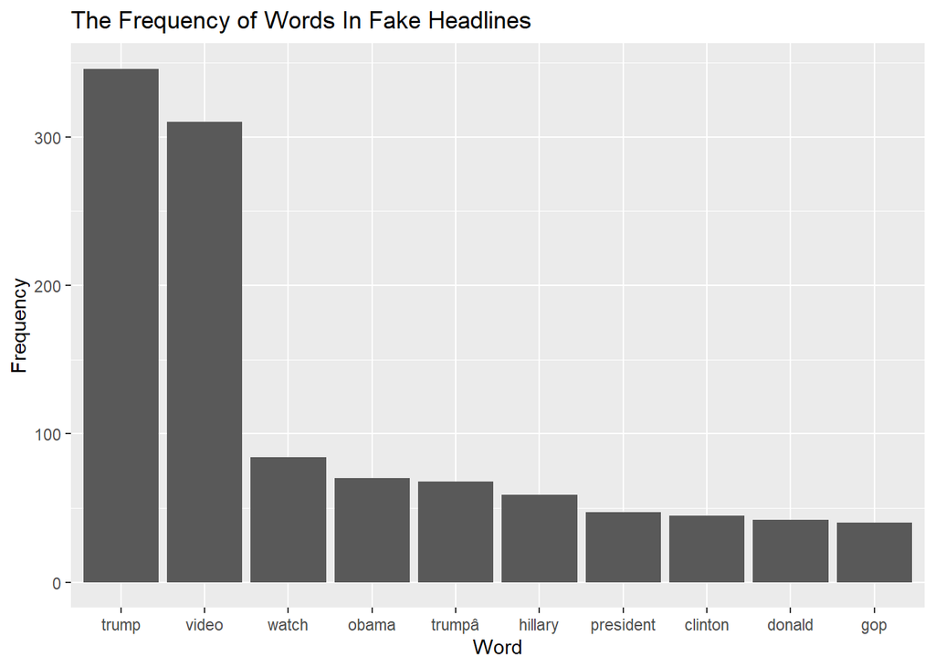

```r
ggplot(fake.word.counts, aes(x = reorder(word, - n), y = n)) + geom_col() +
  xlab("Word")+
  ylab("Frequency")+
  ggtitle("The Frequency of Words In Fake Headlines")
```

These barplots quantify what we saw in the word clouds. “Trump” and “video” are by far the most prominent words in fake headlines. Six out of the top ten most prominent words in the fake headlines represent public figures, while only two of the top ten most prominent words in the real headlines represent public figures.

## Variable/Word Selection

Before diving into our lovely assortment of models, let’s employ a variable selection technique to find the most important predictors for the truthfullness of a headline. Our goal is to keep the variables/words that distinguish headlines, and eliminate the variables/words that add unwanted noise.

For variable/word selection, I will fit a random forest model with default parameters to all of my data, get the mean decrease in accuracy for every word and keep the top 20th percetile words. This is a generalized first step that should give us a great idea of which variables are the most impactful for predicting real or fake.

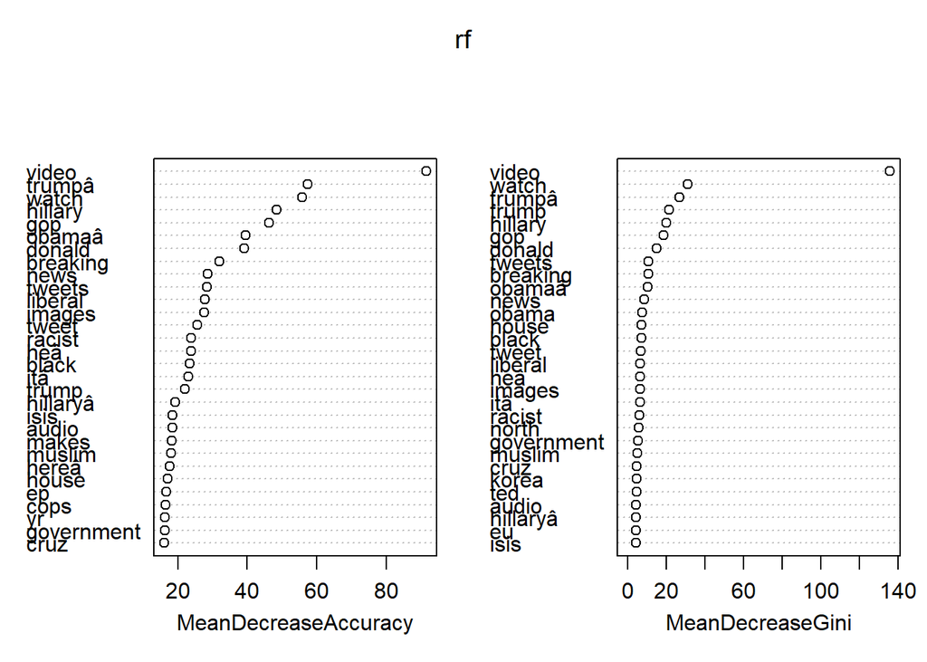

```r
set.seed(1)
rf = randomForest(truth~.,data=df, importance =TRUE)
varImpPlot(rf)
```

As shown by the importance plot, the word “video” is shown to have the most influence on our predictions with a mean decrease in accuracy of 91.476. This means that removing “video” from the model results in 91.476 additional missclassifications on average, a huge amount!

```r
mda <- importance(rf, type = 1)
df.subset <- ((df %>% select(-truth))[,which(mda > quantile(mda, 0.8))])
df.subset$truth = df$truth
```

## Model Evalutation

Now, time for the fun part! Let’s see how all the different classification models perform on our data. For every model, I will measure performance by estimating the missclassification rate and calculating the area under the ROC curve. I will measure performance across three different training set sizes, 60% of the original data, 70%, and 80%. If a model requires hyperparamter tuning, I will test different hyperparameter values on the 70% training set, then use the resultant best hyperparameter value to evaluate performance on the other training set sizes.

For all models, I will keep the decision threshold at 0.5 because there is close to an equal amount of real and fake articles in our data.

These are the models I will be evaluating: * Logistic Regression * Linear Discriminant Analysis * Quadratic Discriminant Analysis * K-Nearest Neighbors * Classification Tree * Random Forest * Boosted Classification Tree * Neural Network * Support Vector Machine

#### Training Set Splits

```r
df.subset = read.csv("C:/Users/Computadora/Documents/434 final/files/tf_idf_subset.csv")

set.seed(1)
train60_i <- sample(1:nrow(df.subset), size = round(nrow(df.subset)*0.60))
train60 <- df.subset[train60_i,]
test60 <- df.subset[-train60_i,]

train70_i <- sample(1:nrow(df.subset), size = round(nrow(df.subset)*0.7))
train70 <- df.subset[train70_i,]
test70 <- df.subset[-train70_i,]

train80_i <- sample(1:nrow(df.subset), size = round(nrow(df.subset)*0.8))
train80 <- df.subset[train80_i,]
test80 <- df.subset[-train80_i,]

train.dfs <- list(train60, train70, train80)
test.dfs <- list(test60, test70, test80)

model.results <- data.frame(Size = c("60%", "70%", "80%"),
                     Error = c(NA, NA, NA),
                     AUC = c(NA, NA, NA))
```

#### Logistic Regression

```r
for (i in 1:3){
  logis <- glm(truth ~ ., data = train.dfs[[i]], family = "binomial")

  prob <- predict(logis, test.dfs[[i]], type = "response")
  pred <- ifelse(prob > 0.5, "real", "fake")
  error <- mean(pred != test.dfs[[i]]$truth)

  model.results$Error[i] <- error
  model.results$AUC[i] <- auc(as.numeric(test.dfs[[i]]$truth == "real"), as.numeric(pred == "real"))
}

model.results
```

```
##   Size  Error       AUC
## 1  60% 0.1350 0.8630017
## 2  70% 0.1250 0.8723291
## 3  80% 0.0975 0.9023851
```

#### Linear Discriminant Analysis

```r
for (i in 1:3){
  if (i == 1){
    lda.fit <- lda(truth ~ ., data = train.dfs[[i]][, -c(66, 69)]) #columns 66 and 69 collinear in train60
  } else {
    lda.fit <- lda(truth ~ ., data = train.dfs[[i]])
  }

  pred <- predict(lda.fit, test.dfs[[i]])$class
  error <- mean(pred != test.dfs[[i]]$truth)

  model.results$Error[i] <- error
  model.results$AUC[i] <- auc(as.numeric(test.dfs[[i]]$truth == "real"), as.numeric(pred == "real"))
}

model.results
```

```
##   Size     Error       AUC
## 1  60% 0.1325000 0.8648283
## 2  70% 0.1216667 0.8750000
## 3  80% 0.1325000 0.8671342
```

#### Quadratic Discriminant Analysis

I tried running the model on using all 200 words, but I kept getting errors saying there is rank deficiency. I assume this has to do with the collinearity between variables. I tried running the model with so many different subsets of variables, and basically, every subset I tried resulted in the same error. So I am using a very small number of predictors for QDA. These results will not be considered.

```r
for (i in 1:3){
  qda.train.df <- train.dfs[[i]] %>% dplyr::select(trump, watch, obama)
  qda.test.df <- test.dfs[[i]] %>% dplyr::select(trump, watch, obama)
  qda.train.df$truth <- train.dfs[[i]]$truth
  qda.test.df$truth <- test.dfs[[i]]$truth

  qda.fit <- qda(truth ~ ., data = qda.train.df)

  pred <- predict(qda.fit, qda.test.df)$class
  error <- mean(pred != qda.test.df$truth)

  model.results$Error[i] <- error
  model.results$AUC[i] <- auc(as.numeric(qda.test.df$truth == "real"), as.numeric(pred == "real"))
}

model.results
```

```
##   Size     Error       AUC
## 1  60% 0.4450000 0.5414623
## 2  70% 0.4416667 0.5400641
## 3  80% 0.4475000 0.5503763
```

#### K-Nearest Neighbors

First, Let’s find the best value of K.

```r
ks <- c(2, 3, 4, seq(5, 100, 5))
test.errors <- c()

for (i in 1:length(ks)) {
    knn.pred <- knn(train70[,-201],
                    test70[,-201],
                    train70$truth,
                    k = ks[i])

    test.errors[i] <- mean(knn.pred != test70$truth)
}
```

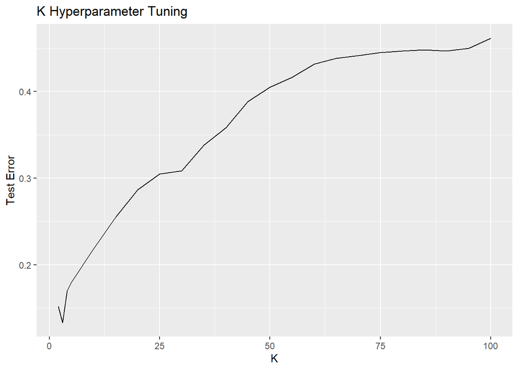

```r
ggplot(, aes(x = ks, y = test.errors)) + geom_line() +
  ggtitle("K Hyperparameter Tuning") +
  xlab("K") +
  ylab("Test Error")
```

```r
ks[which.min(test.errors)]
```

```
## [1] 3
```

K = 3 results in the lowest test error.

```r
for (i in 1:3){
  pred <- knn(train.dfs[[i]][,-201],
              test.dfs[[i]][,-201],
              train.dfs[[i]]$truth,
              k = 3)

  error <- mean(pred != test.dfs[[i]]$truth)

  model.results$Error[i] <- error
  model.results$AUC[i] <- auc(as.numeric(test.dfs[[i]]$truth == "real"), as.numeric(pred == "real"))
}

model.results
```

```
##   Size     Error       AUC
## 1  60% 0.1575000 0.8390551
## 2  70% 0.1366667 0.8596421
## 3  80% 0.1450000 0.8546714
```

#### Classification Tree

First, let’s use cross validation to determine the optimal level of tree complexity.

```r
tree =tree(truth~., train70)
cv = cv.tree(tree, FUN=prune.misclass)
```

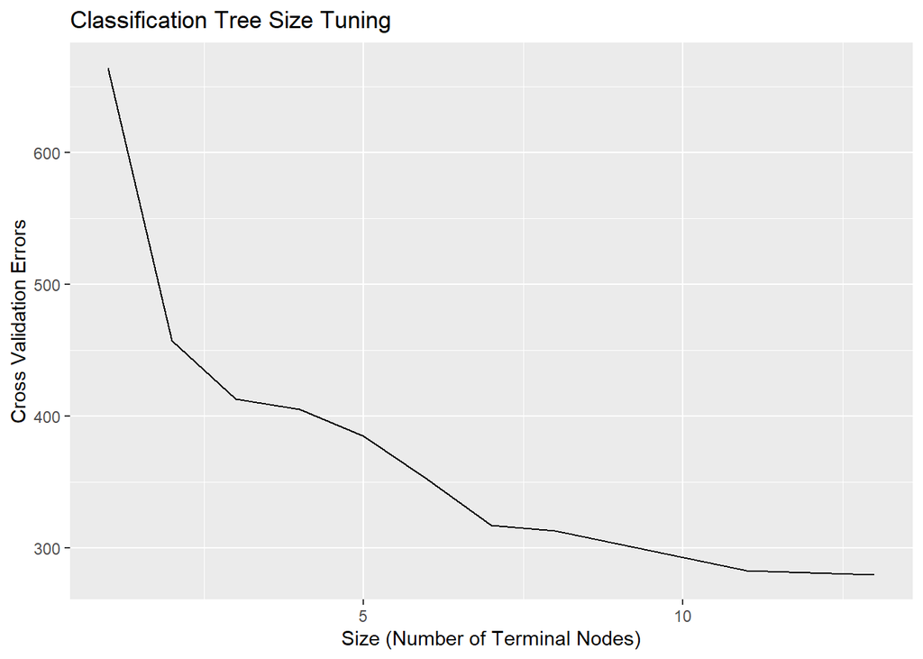

```r
ggplot(, aes(x = cv$size, y = cv$dev)) + geom_line() +
  ggtitle("Classification Tree Size Tuning") +
  xlab("Size (Number of Terminal Nodes)") +
  ylab("Cross Validation Errors")
```

We can see that 13 terminal nodes results in the least cross validation errors. This means that pruning the tree is not expected to improve prediction accuracy.

```r
for (i in 1:3){
  tree <- tree(truth~., train.dfs[[i]])

  pred <- predict(tree, test.dfs[[i]], type = "class", best = 13)

  error <- mean(pred != test.dfs[[i]]$truth)

  model.results$Error[i] <- error
  model.results$AUC[i] <- auc(as.numeric(test.dfs[[i]]$truth == "real"), as.numeric(pred == "real"))
}

model.results
```

```
##   Size     Error       AUC
## 1  60% 0.2087500 0.7856946
## 2  70% 0.2183333 0.7732372
## 3  80% 0.2125000 0.7865572
```

#### Random Forest

First, let’s try different numbers of predictors at each split and see which results in the lowest validation set error. Let’s try sqrt(p), p/3, and p/2 predictors at each split.

```r
set.seed(1)
#sqrt(p)
rf = randomForest(truth~., data=train70, mtry=round(sqrt(ncol(train70))))
pred = (predict(rf, newdata = test70))
mean(pred != test70$truth)
```

```
## [1] 0.1366667
```

```r
#p/3
rf = randomForest(truth~., data=train70, mtry=round(ncol(train70) / 3))
pred = (predict(rf, newdata = test70))
mean(pred != test70$truth)
```

```
## [1] 0.1433333
```

```r
#p/2
rf = randomForest(truth~., data=train70, mtry=round(ncol(train70) / 2))
pred = (predict(rf, newdata = test70))
mean(pred != test70$truth)
```

```
## [1] 0.145
```

Using sqrt(p) predictors at each spllit resulted in the lowest validation error.

```r
for (i in 1:3){
  rf = randomForest(truth~., data=train.dfs[[i]], mtry=round(sqrt(ncol(train.dfs[[i]]))))

  pred = predict(rf, newdata = test.dfs[[i]])

  error <- mean(pred != test.dfs[[i]]$truth)

  model.results$Error[i] <- error
  model.results$AUC[i] <- auc(as.numeric(test.dfs[[i]]$truth == "real"), as.numeric(pred == "real"))
}

model.results
```

```
##   Size     Error       AUC
## 1  60% 0.1350000 0.8624012
## 2  70% 0.1433333 0.8518964
## 3  80% 0.1225000 0.8771344
```

#### Boosted Classification Tree

Now, let’s try different values of the shrinkage parameter $\lambda$ and see which value results in the lowest validation set error.

```r
lambdas <- c(.0001, .001, .1, .3, .5)
errors <- c()

for (i in 1:length(lambdas)) {
    boost <- gbm(truth~.,
                 data = train70 %>% mutate(truth = as.numeric(truth == "real")),
                 distribution = "bernoulli",
                 n.trees = 1000,
                 shrinkage = lambdas[i])

    prob <- predict(boost,
                    newdata = test70 %>% mutate(truth = as.numeric(truth == "real")),
                    n.trees = 1000,
                    type = "response")

    pred <- ifelse(prob > 0.5, "real", "fake")

    errors[i] <- mean(pred != test70$truth)
}
```

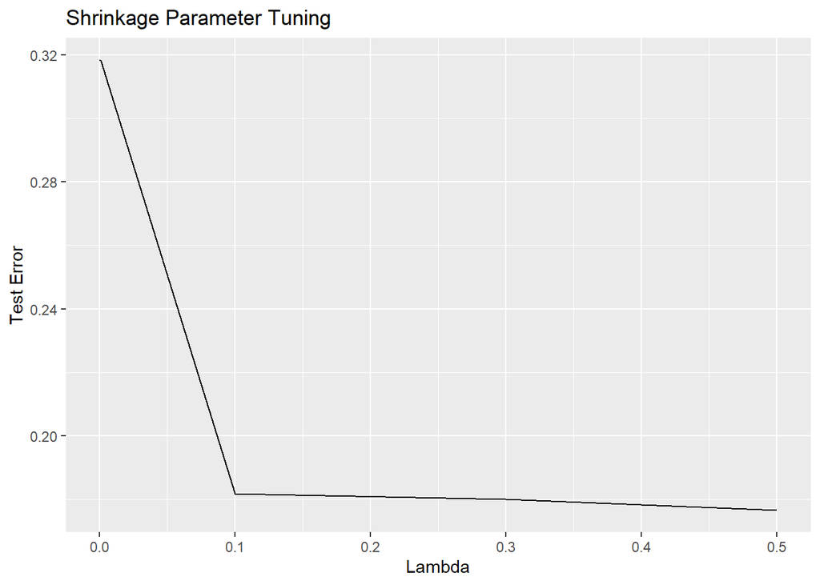

```r
ggplot(, aes(x = lambdas, y = errors)) + geom_line() +
  ggtitle("Shrinkage Parameter Tuning") +
  xlab("Lambda") +
  ylab("Test Error")
```

```r
for (i in 1:3){
  boost <- gbm(truth~.,
                 data = train.dfs[[i]] %>% mutate(truth = as.numeric(truth == "real")),
                 distribution = "bernoulli",
                 n.trees = 1000,
                 shrinkage = 0.3)

  prob <- predict(boost,
                    newdata = test.dfs[[i]] %>% mutate(truth = as.numeric(truth == "real")),
                    n.trees = 1000,
                    type = "response")

  pred <- ifelse(prob > 0.5, "real", "fake")

  errors[i] <- mean(pred != test.dfs[[i]]$truth)

  model.results$Error[i] <- error
  model.results$AUC[i] <- auc(as.numeric(test.dfs[[i]]$truth == "real"), as.numeric(pred == "real"))
}

model.results
```

```
##   Size  Error       AUC
## 1  60% 0.1225 0.8256306
## 2  70% 0.1225 0.8201122
## 3  80% 0.1225 0.8594965
```

#### Neural Network

Let’s try different numbers of units in the hidden layer and see which results in the lowest validation set error.

```r
units <- seq(10, 50, 10)
errors <- c()

for (i in 1:length(units)){
  nn <- nnet(truth~.,
             data = train70,
             size = units[i],
             linout = FALSE,
             MaxNWts = 11000)

  pred <- predict(nn, newdata = test70, type = 'class')
  errors[i] <- mean(pred != test70$truth)
}
```

```r
units.plot <- ggplot(, aes(x = units, y = errors)) + geom_line() +
  ggtitle("Hidden Units Tuning") +
  xlab("Hidden Units") +
  ylab("Test Error")
```

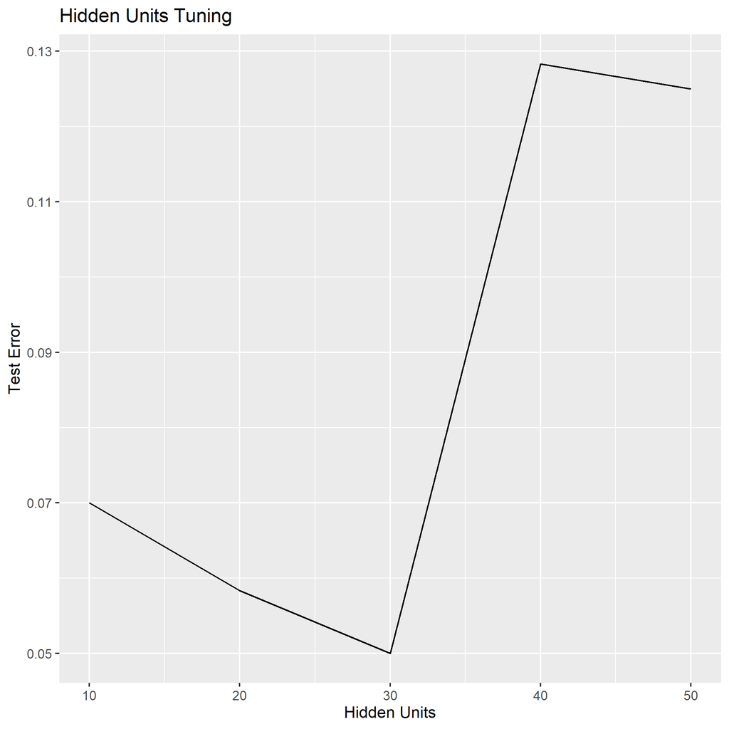

```r
units.plot
```

```r
for (i in 1:3){
  nn <- nnet(truth~.,
             data = train.dfs[[i]],
             size = 10,
             linout = FALSE,
             MaxNWts = 5000)

  pred <- predict(nn, newdata = test.dfs[[i]], type = 'class')
  errors[i] <- mean(pred != test.dfs[[i]]$truth)

  model.results$Error[i] <- error
  model.results$AUC[i] <- auc(as.numeric(test.dfs[[i]]$truth == "real"), as.numeric(pred == "real"))
}
```

```r
model.results
```

[output not shown]

### Support Vector Machine

Let’s use cross validation to see what the best combination of `cost` and `gamma` is for a support vector machine with a linear kernel.

```r
tune.out = tune(svm,
                truth~.,
                data=train70,
                kernel ="linear",
                scale = F,
                ranges=list(cost=c(0.1,1,10),
                            gamma=c(0.5,1,2)))
summary(tune.out)
```

```
##
## Parameter tuning of 'svm':
##
## - sampling method: 10-fold cross validation
##
## - best parameters:
##  cost gamma
##    10   0.5
##
## - best performance: 0.1235714
##
## - Detailed performance results:
##   cost gamma     error dispersion
## 1  0.1   0.5 0.1864286 0.05923262
## 2  1.0   0.5 0.1435714 0.03202359
## 3 10.0   0.5 0.1235714 0.02429272
## 4  0.1   1.0 0.1864286 0.05923262
## 5  1.0   1.0 0.1435714 0.03202359
## 6 10.0   1.0 0.1235714 0.02429272
## 7  0.1   2.0 0.1864286 0.05923262
## 8  1.0   2.0 0.1435714 0.03202359
## 9 10.0   2.0 0.1235714 0.02429272
```

`cost = 10` and gamma `0.5` result in the lowest cross validation error.

```r
for (i in 1:3){
  svmfit = svm(truth~.,
             data=test.dfs[[i]],
             kernel = "linear",
             gamma = 0.5,
             cost = 10)

  pred <- predict(svmfit, test.dfs[[i]])
  errors[i] <- mean(pred != test.dfs[[i]]$truth)

  model.results$Error[i] <- error
  model.results$AUC[i] <- auc(as.numeric(test.dfs[[i]]$truth == "real"), as.numeric(pred == "real"))
}

model.results
```

```
##   Size  Error       AUC
## 1  60% 0.1225 0.9288109
## 2  70% 0.1225 0.9396368
## 3  80% 0.1225 0.9497737
```

## Results

First, let’s look at how model performance changes as the size of the training set changes. Specifically, we’re going to average performance metrics across all models and plot it against training set size.

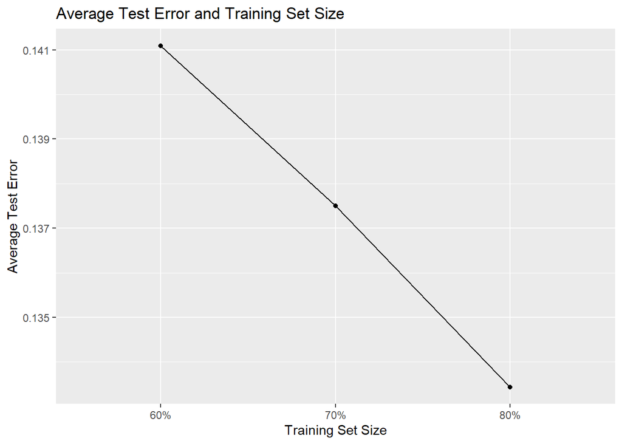

```r
ggplot(results %>% group_by(Size) %>% summarise(`Average Test Error` = mean(Error)),
       aes(x = Size, y = `Average Test Error`, group = 1)) +
  geom_line() +
  geom_point() +
  ggtitle("Average Test Error and Training Set Size") +
  xlab("Training Set Size")
```

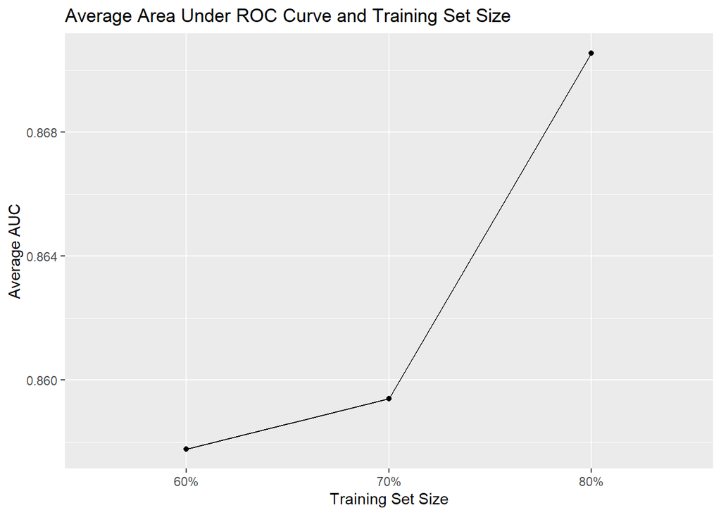

```r
ggplot(results %>% group_by(Size) %>% summarise(`Average AUC` = mean(AUC)),
       aes(x = Size, y = `Average AUC`, group = 1)) +
  geom_line() +
  geom_point() +
  ggtitle("Average Area Under ROC Curve and Training Set Size") +
  xlab("Training Set Size")
```

#### Key Takeaways

- Model performance increases as training set size increases.
  - Test Error decreases
  - AUC increases
- Higher training set size means more data for models to learn from. More data to learn from means better model performance.

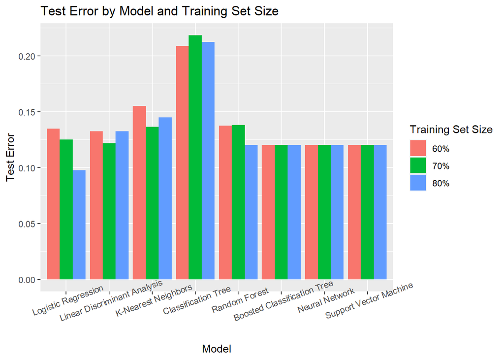

```r
ggplot(results, aes(fill = Size, x = factor(Method, level = unique(Method)), y = Error)) +
  geom_bar(position = "dodge", stat = "identity") +
  ggtitle("Test Error by Model and Training Set Size") +
  xlab("Model") +
  ylab("Test Error") +
  theme(axis.text.x = element_text(angle = 20)) +
  labs(fill = "Training Set Size")
```

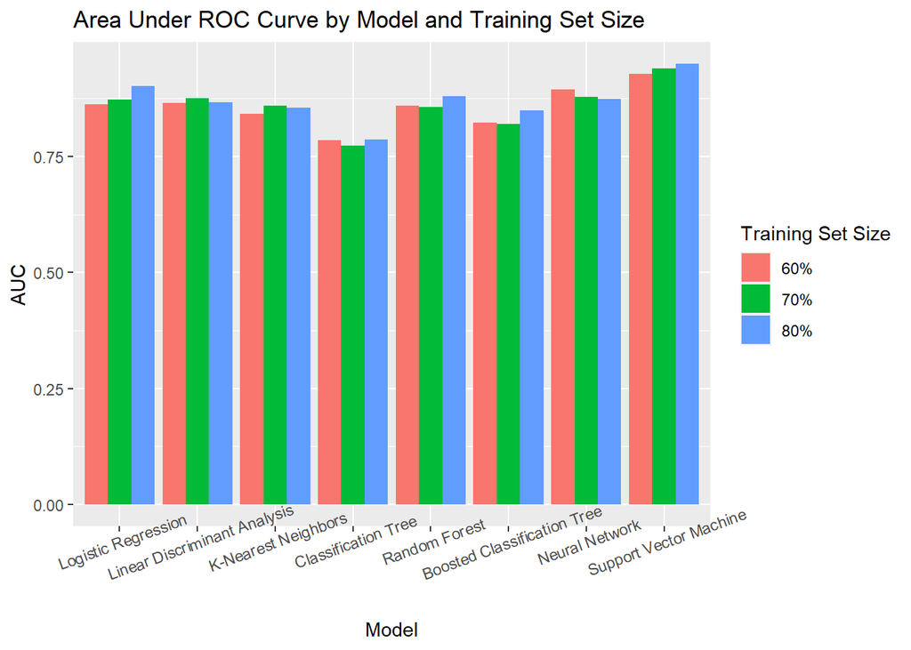

```r
ggplot(results, aes(fill = Size, x = factor(Method, level = unique(Method)), y = AUC)) +
  geom_bar(position = "dodge", stat = "identity") +
  ggtitle("Area Under ROC Curve by Model and Training Set Size") +
  xlab("Model") +
  ylab("AUC") +
  theme(axis.text.x = element_text(angle = 20)) +
  labs(fill = "Training Set Size")
```

### Conclusion

We should be able to spot fake headlines from a mile away. You know its bad when a single classification tree almost reaches 80% accuracy. In our initial exploration of the data, we were able to see the big difference between fake and real headlines. Fake headlines entice the reader with videos and divisive public figures, probably because the headlines are so egregious that they need to claim video evidence. Real headlines tend have a more informative tone and purpose, covering variety of topics. The models we tested were able to pick up on those differences easily with the best models almost reaching 90% predictive accuracy. Even when only using 4% of the 44,689 total headlines we could have used, the models are still able to perform.

Thank you for taking the time to read this report! My abused laptop and I appreciate it!